# Discussion 4

## Task 1

1. Please list out their definitions:
- Independence refers to a situation where two or more events or variables are not influenced by each other.

  𝑃(𝐴∩𝐵)=𝑃(𝐴).𝑃(𝐵)
- Mutually exclusive events are events that cannot occur simultaneously.

  𝑃(𝐴∩𝐵)=0

  ⇒𝑃(𝐴∩𝐵)=𝑃(𝐴).𝑃(𝐵)=0

  ⇒𝑃(𝐴).𝑃(𝐵)=0

So, for two events, if one event happens to not occur, then the events are independent and mutually exclusive. They are both time of occurence and realisation dependent.

2. Choose an experiment (or different experiments), and describe the outcomes of the experiment (i.e. sample space) a bit atleast. Then, give us an example of two events that are
- Mutually exclusive
- Not mutually exclusive
- Independent
- Not independent

*Experiment*: Tossing a Fair Six-Sided Die

*Sample* *Space* *(Outcomes)*: {1, 2, 3, 4, 5 ,6}

i. Mutually Exclusive Events:

- Events A: Getting an even number (2, 4, 6)
- Events B: Getting an odd number (1, 3, 5)

ii. Not Mutually Exclusive Events:

- Events C: Getting a number less than 4. (1, 2, 3)
- Events D: Getting an even number (2, 4, 6)

iii. Independent Events:

- Events E: Getting a 3 or higher (3, 4, 5, 6)
- Events F: Getting an even number (2, 4, 6)

iv. Not Independent Events:

- Events G: Getting an even number (2, 4, 6)
- Events H: Getting a number greater than 5. (6)

## Task 2

1. Adding the dataset to the global environment

   ```r
   #Clearing the global environment
   rm(list = ls())
   ```

```r
db = read.csv('/Users/aritraray/Downloads/train.csv')
```

```r
# Creating a three-way table
table(db$Survived,
      db$Sex,
      db$Pclass
      )
```

```
## , ,  = 1
##
##
##     female male
##   0      3   77
##   1     91   45
##
## , ,  = 2
##
##
##     female male
##   0      6   91
##   1     70   17
##
## , ,  = 3
##
##
##     female male
##   0     72  300
##   1     72   47
```

2. Recreate the same table using pivot charts in Excel.

   Passenger class in columns:

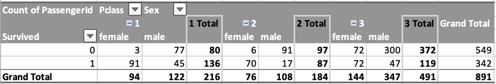

Passenger class in rows:

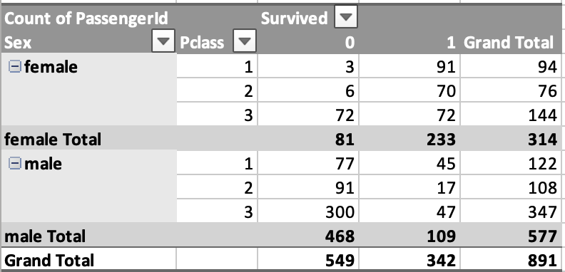

- There is a noticeable pattern where most of the passengers of Pclass = 3, did not survive.
- A larger number of male passengers died, compared to female passengers.